# Replication Code for Peer Grading

```r
library(foreign)
library(stargazer)
library(arm)
library(rms)
library(msm)
library(systemfit)
library(xtable)
library(gtools)
library(multiwayvcov)
library(numDeriv)
library(interplot)
library(modmarg)
library(tidyverse)
library(stats)
library(haven)
library(systemfit)
library(nnet)
library(sjmisc)
library(maptools)
library(rgeos)
library(Imap)
library(spatstat)
library(StatMeasures)
library(sandwich)
```

```r
load("datawork.RData")
```

```r
#reclassifying municipality and district as factor variables
table$id_mun<-factor(table$id_mun)
table$id_dist<-factor(table$id_dist)
```

The original model:

```r
benchmarkPRI.1.proximity <- lm( EPNa ~ proximity*PRIstr*highTURNOUT+
                        proximity*PRDstr*highTURNOUT+proximity*PANstr*highTURNOUT+
                         PRI09a+PRD09a+PAN09a+PART09+
                         lnpop+P18+P65+area+density+INDIGENOUS+CATHOLIC+NONRELIGIOUS+
                         EDUCATION+POSTEDUC+ILLITERACY+PROM_HNV+
                         PEAprop+PEAfemale+NOINSURANCE+FEMALEJEFA+
                         PERROOM+DIRTFLOOR+SERVICES+NO_SERVICES+
                         CAR+CELULAR+INTERNET+
                         id_mun, data=table, x=TRUE, y=TRUE)


benchmarkPRD.1.proximity <- lm( AMLOa ~ proximity*PRIstr*highTURNOUT+
                        proximity*PRDstr*highTURNOUT+proximity*PANstr*highTURNOUT+
                         PRI09a+PRD09a+PAN09a+PART09+
                         lnpop+P18+P65+area+density+INDIGENOUS+CATHOLIC+NONRELIGIOUS+
                         EDUCATION+POSTEDUC+ILLITERACY+PROM_HNV+
                         PEAprop+PEAfemale+NOINSURANCE+FEMALEJEFA+
                         PERROOM+DIRTFLOOR+SERVICES+NO_SERVICES+
                         CAR+CELULAR+INTERNET+
                         id_mun, data=table, x=TRUE, y=TRUE)


benchmarkPAN.1.proximity <- lm( JVMa ~ proximity*PRIstr*highTURNOUT+proximity*PRDstr*highTURNOUT+proximity*PANstr*highTURNOUT+
                         PRI09a+PRD09a+PAN09a+PART09+
                         lnpop+P18+P65+area+density+INDIGENOUS+CATHOLIC+NONRELIGIOUS+
                         EDUCATION+POSTEDUC+ILLITERACY+PROM_HNV+
                         PEAprop+PEAfemale+NOINSURANCE+FEMALEJEFA+
                         PERROOM+DIRTFLOOR+SERVICES+NO_SERVICES+
                         CAR+CELULAR+INTERNET+
                         id_mun, data=table, x=TRUE, y=TRUE)



benchmarkPART.1.proximity <- lm( PART ~ proximity*PRIstr*highTURNOUT+proximity*PRDstr*highTURNOUT+proximity*PANstr*highTURNOUT+
                          PRI09a+PRD09a+PAN09a+PART09+
                          lnpop+P18+P65+area+density+INDIGENOUS+CATHOLIC+NONRELIGIOUS+
                          EDUCATION+POSTEDUC+ILLITERACY+PROM_HNV+
                          PEAprop+PEAfemale+NOINSURANCE+FEMALEJEFA+
                          PERROOM+DIRTFLOOR+SERVICES+NO_SERVICES+
                          CAR+CELULAR+INTERNET+
                          id_mun, data=table, x=TRUE, y=TRUE)
```

Now with pure distance:

```r
benchmarkPRI.1.distance <- lm( EPNa ~ distance*PRIstr*highTURNOUT+
                        distance*PRDstr*highTURNOUT+distance*PANstr*highTURNOUT+
                         PRI09a+PRD09a+PAN09a+PART09+
                         lnpop+P18+P65+area+density+INDIGENOUS+CATHOLIC+NONRELIGIOUS+
                         EDUCATION+POSTEDUC+ILLITERACY+PROM_HNV+
                         PEAprop+PEAfemale+NOINSURANCE+FEMALEJEFA+
                         PERROOM+DIRTFLOOR+SERVICES+NO_SERVICES+
                         CAR+CELULAR+INTERNET+
                         id_mun, data=table, x=TRUE, y=TRUE)


#The same model but testing for other parties:

benchmarkPRD.1.distance <- lm( AMLOa ~ distance*PRIstr*highTURNOUT+
                        distance*PRDstr*highTURNOUT+distance*PANstr*highTURNOUT+
                         PRI09a+PRD09a+PAN09a+PART09+
                         lnpop+P18+P65+area+density+INDIGENOUS+CATHOLIC+NONRELIGIOUS+
                         EDUCATION+POSTEDUC+ILLITERACY+PROM_HNV+
                         PEAprop+PEAfemale+NOINSURANCE+FEMALEJEFA+
                         PERROOM+DIRTFLOOR+SERVICES+NO_SERVICES+
                         CAR+CELULAR+INTERNET+
                         id_mun, data=table, x=TRUE, y=TRUE)


benchmarkPAN.1.distance <- lm( JVMa ~ distance*PRIstr*highTURNOUT+distance*PRDstr*highTURNOUT+distance*PANstr*highTURNOUT+
                         PRI09a+PRD09a+PAN09a+PART09+
                         lnpop+P18+P65+area+density+INDIGENOUS+CATHOLIC+NONRELIGIOUS+
                         EDUCATION+POSTEDUC+ILLITERACY+PROM_HNV+
                         PEAprop+PEAfemale+NOINSURANCE+FEMALEJEFA+
                         PERROOM+DIRTFLOOR+SERVICES+NO_SERVICES+
                         CAR+CELULAR+INTERNET+
                         id_mun, data=table, x=TRUE, y=TRUE)



benchmarkPART.1.distance <- lm( PART ~ distance*PRIstr*highTURNOUT+distance*PRDstr*highTURNOUT+distance*PANstr*highTURNOUT+
                          PRI09a+PRD09a+PAN09a+PART09+
                          lnpop+P18+P65+area+density+INDIGENOUS+CATHOLIC+NONRELIGIOUS+
                          EDUCATION+POSTEDUC+ILLITERACY+PROM_HNV+
                          PEAprop+PEAfemale+NOINSURANCE+FEMALEJEFA+
                          PERROOM+DIRTFLOOR+SERVICES+NO_SERVICES+
                          CAR+CELULAR+INTERNET+
                          id_mun, data=table, x=TRUE, y=TRUE)
```

Making a quantile model:

```r
seq <- quantile(table$distance)
seq[5] <- 20

table$Distance.Quant <- cut(table$distance, breaks = seq)

table$Distance.Quant <- as.factor(table$Distance.Quant)

benchmarkPRI.1.Quantile <- lm( EPNa ~ Distance.Quant*PRIstr*highTURNOUT+
                        Distance.Quant*PRDstr*highTURNOUT+Distance.Quant*PANstr*highTURNOUT+
                         PRI09a+PRD09a+PAN09a+PART09+
                         lnpop+P18+P65+area+density+INDIGENOUS+CATHOLIC+NONRELIGIOUS+
                         EDUCATION+POSTEDUC+ILLITERACY+PROM_HNV+
                         PEAprop+PEAfemale+NOINSURANCE+FEMALEJEFA+
                         PERROOM+DIRTFLOOR+SERVICES+NO_SERVICES+
                         CAR+CELULAR+INTERNET+
                         id_mun, data=table, x=TRUE, y=TRUE)


#The same model but testing for other parties:

benchmarkPRD.1.Quantile <- lm(AMLOa ~ Distance.Quant*PRIstr*highTURNOUT+
                        Distance.Quant*PRDstr*highTURNOUT+Distance.Quant*PANstr*highTURNOUT+
                         PRI09a+PRD09a+PAN09a+PART09+
                         lnpop+P18+P65+area+density+INDIGENOUS+CATHOLIC+NONRELIGIOUS+
                         EDUCATION+POSTEDUC+ILLITERACY+PROM_HNV+
                         PEAprop+PEAfemale+NOINSURANCE+FEMALEJEFA+
                         PERROOM+DIRTFLOOR+SERVICES+NO_SERVICES+
                         CAR+CELULAR+INTERNET+
                         id_mun, data=table, x=TRUE, y=TRUE)


benchmarkPAN.1.Quantile <- lm( JVMa ~ Distance.Quant*PRIstr*highTURNOUT+Distance.Quant*PRDstr*highTURNOUT+Distance.Quant*PANstr*highTURNOUT+
                         PRI09a+PRD09a+PAN09a+PART09+
                         lnpop+P18+P65+area+density+INDIGENOUS+CATHOLIC+NONRELIGIOUS+
                         EDUCATION+POSTEDUC+ILLITERACY+PROM_HNV+
                         PEAprop+PEAfemale+NOINSURANCE+FEMALEJEFA+
                         PERROOM+DIRTFLOOR+SERVICES+NO_SERVICES+
                         CAR+CELULAR+INTERNET+
                         id_mun, data=table, x=TRUE, y=TRUE)



benchmarkPART.1.Quantile <- lm( PART ~ Distance.Quant*PRIstr*highTURNOUT+Distance.Quant*PRDstr*highTURNOUT+Distance.Quant*PANstr*highTURNOUT+
                          PRI09a+PRD09a+PAN09a+PART09+
                          lnpop+P18+P65+area+density+INDIGENOUS+CATHOLIC+NONRELIGIOUS+
                          EDUCATION+POSTEDUC+ILLITERACY+PROM_HNV+
                          PEAprop+PEAfemale+NOINSURANCE+FEMALEJEFA+
                          PERROOM+DIRTFLOOR+SERVICES+NO_SERVICES+
                          CAR+CELULAR+INTERNET+
                          id_mun, data=table, x=TRUE, y=TRUE)
```

Finally, a model with coarsened deciles:

```r
seq <- quantile(table$distance, prob = seq(0, 1, length = 11))

seq[11] <- 20
table$Distance.Decile <- cut(table$distance, breaks = seq)

table$Distance.Decile <- as.factor(table$Distance.Decile)

benchmarkPRI.1.Decile <- lm( EPNa ~ Distance.Decile*PRIstr*highTURNOUT+
                        Distance.Decile*PRDstr*highTURNOUT+Distance.Decile*PANstr*highTURNOUT+
                         PRI09a+PRD09a+PAN09a+PART09+
                         lnpop+P18+P65+area+density+INDIGENOUS+CATHOLIC+NONRELIGIOUS+
                         EDUCATION+POSTEDUC+ILLITERACY+PROM_HNV+
                         PEAprop+PEAfemale+NOINSURANCE+FEMALEJEFA+
                         PERROOM+DIRTFLOOR+SERVICES+NO_SERVICES+
                         CAR+CELULAR+INTERNET+
                         id_mun, data=table, x=TRUE, y=TRUE)


#The same model but testing for other parties:

benchmarkPRD.1.Decile <- lm(AMLOa ~ Distance.Decile*PRIstr*highTURNOUT+
                        Distance.Decile*PRDstr*highTURNOUT+Distance.Decile*PANstr*highTURNOUT+
                         PRI09a+PRD09a+PAN09a+PART09+
                         lnpop+P18+P65+area+density+INDIGENOUS+CATHOLIC+NONRELIGIOUS+
                         EDUCATION+POSTEDUC+ILLITERACY+PROM_HNV+
                         PEAprop+PEAfemale+NOINSURANCE+FEMALEJEFA+
                         PERROOM+DIRTFLOOR+SERVICES+NO_SERVICES+
                         CAR+CELULAR+INTERNET+
                         id_mun, data=table, x=TRUE, y=TRUE)


benchmarkPAN.1.Decile <- lm( JVMa ~ Distance.Decile*PRIstr*highTURNOUT+Distance.Decile*PRDstr*highTURNOUT+Distance.Decile*PANstr*highTURNOUT+
                         PRI09a+PRD09a+PAN09a+PART09+
                         lnpop+P18+P65+area+density+INDIGENOUS+CATHOLIC+NONRELIGIOUS+
                         EDUCATION+POSTEDUC+ILLITERACY+PROM_HNV+
                         PEAprop+PEAfemale+NOINSURANCE+FEMALEJEFA+
                         PERROOM+DIRTFLOOR+SERVICES+NO_SERVICES+
                         CAR+CELULAR+INTERNET+
                         id_mun, data=table, x=TRUE, y=TRUE)



benchmarkPART.1.Decile <- lm( PART ~ Distance.Decile*PRIstr*highTURNOUT+Distance.Decile*PRDstr*highTURNOUT+Distance.Decile*PANstr*highTURNOUT+
                          PRI09a+PRD09a+PAN09a+PART09+
                          lnpop+P18+P65+area+density+INDIGENOUS+CATHOLIC+NONRELIGIOUS+
                          EDUCATION+POSTEDUC+ILLITERACY+PROM_HNV+
                          PEAprop+PEAfemale+NOINSURANCE+FEMALEJEFA+
                          PERROOM+DIRTFLOOR+SERVICES+NO_SERVICES+
                          CAR+CELULAR+INTERNET+
                          id_mun, data=table, x=TRUE, y=TRUE)
```

Calculating RSEs for each model:

```r
covBMprox <- cluster.vcov(benchmarkPRI.1.proximity, table$id_dist)
covBMdist <- cluster.vcov(benchmarkPRI.1.distance, table$id_dist)
covBMquantiles <- cluster.vcov(benchmarkPRI.1.Quantile, table$id_dist)
covBMdeciles <- cluster.vcov(benchmarkPRI.1.Decile, table$id_dist)
```

### Table 1 - All Distance Models in Comparison - Including as an appendix but not in the text

```r
stargazer(coeftest(benchmarkPRI.1.proximity, covBMprox), coeftest(benchmarkPRI.1.distance, covBMdist), coeftest(benchmarkPRI.1.Quantile, covBMquantiles), coeftest(benchmarkPRI.1.Decile, covBMdeciles),style = "qje", star.cutoffs = c(0.05, 0.01, 0.001), type = "text", digits=3,
          covariate.labels = c("Proximity", "PRI stronghold", "High Mobilization", "PRD stronghold","PAN stronghold", "PRI 2009", "PRD2009", "PAN2009", "Turnout 2009", "Population Log", "Population over 18 ",
                               "Population over 65", "Area", "Density", "Indigenous","Catholic","Nonreligious","Education","College degree","Illiteracy","Inhabitants per house","Population in the labor market",
                               "Female population in the labor market", "No insurance","Female head of household","Inhabitants per room", "Dirt floor", "All services", "No services", "Car", "Mobile phone", "Internet", "ACULCO" , "ALMOLOYA DE JUAREZ " ,
                               "ALMOLOYA DEL RIO" , "AMANALCO" , "AMECAMECA" , "APAXCO" , "ATENCO" , "ATIZAPAN" , "ATIZAPAN DE ZARAGOZA" , "AXAPUSCO" , "AYAPANGO" , "CALIMAYA" , "CAPULHUAC" , "CHALCO" , "CHAPULTEPEC" ,
                               "CHIAUTLA" , "CHICOLOAPAN" , "CHICONCUAC" , "CHIMALHUACAN" , "COACALCO DE BERRIOZABAL" , "COCOTITLAN" , "COYOTEPEC" , "CUAUTITLAN" , "CUAUTITLAN IZCALLI" , "ECATEPEC DE MORELOS" , "HUEHUETOCA",
                               "HUEYPOXTLA" , "HUIXQUILUCAN" , "ISIDRO FABELA" , "IXTAPALUCA" , "IXTLAHUACA" , "JALTENCO" , "JILOTEPEC" , "JILOTZINGO" , "JIQUIPILCO" , "JOCOTITLAN" , "JOQUICINGO" , "JUCHITEPEC" , "LA PAZ" ,
                               "LERMA" , "MELCHOR OCAMPO" , "METEPEC" , "MEXICALTZINGO" , "MORELOS" , "NAUCALPAN DE JUAREZ" , "NEXTLALPAN" , "NEZAHUALCOYOTL" , "NICOLAS ROMERO" , "OCOYOACAC" , "OCUILAN" , "OTUMBA" ,
                               "OTZOLOTEPEC" , "PAPALOTLA" , "POLOTITLAN" , "RAYON" , "SAN ANTONIO LA ISLA" , "SAN FELIPE DEL PROGRESO" , "SAN MARTIN DE LAS PIRAMIDES" , "SAN MATEO ATENCO" , "SOYANIQUILPAN DE JUAREZ" , "TECAMAC" ,
                               "TEMAMATLA" , "TEMASCALAPA" , "TEMOAYA" , "TENANGO DEL AIRE" , "TENANGO DEL VALLE" , "TEOLOYUCAN" , "TEOTIHUACAN" , "TEPETLAOXTOC" , "TEPOTZOTLAN" , "TEQUIXQUIAC" , "TEXCALYACAC" , "TEXCOCO" , "TEZOYUCA" ,
                               "TIANGUISTENCO" , "TLALMANALCO" , "TLALNEPANTLA DE BAZ" , "TOLUCA" , "TONANITLA" , "TULTEPEC" , "TULTITLAN" , "VALLE DE CHALCO SOLIDARIDAD" , "VILLA DE ALLEND" , "VILLA DEL CARBON" , "VILLA VICTORIA" ,
                               "XALATLACO" , "XONACATLAN" , "ZINACANTEPEC" , "ZUMPANGO" , "ALVARO OBREGON" , "AZCAPOTZALCO" , "BENITO JUAREZ" , "COYOACAN" , "CUAJIMALPA DE MORELOS" , "CUAUHTEMOC" , "GUSTAVO A. MADERO" , "IZTACALCO" ,
                               "IZTAPALAPA" , "MAGDALENA CONTRERAS" , "MIGUEL HIDALGO" , "MILPA ALTA" , "TLAHUAC" , "TLALPAN" , "VENUSTIANO CARRANZA" , "XOCHIMILCO"))
```

```
##
## =========================================================================================
##
##                                                   (1)         (2)        (3)       (4)
## -----------------------------------------------------------------------------------------
## Proximity                                        0.001
##                                                 (0.017)
##
## PRI stronghold                                              -0.059*
##                                                             (0.025)
##
## High Mobilization                                                      -0.033
##                                                                        (0.101)
##
## PRD stronghold                                                         -0.124
##                                                                        (0.129)
##
## PAN stronghold                                                         -0.623*
##                                                                        (0.263)
##
## PRI 2009                                                                          0.007
##                                                                                  (0.108)
##
## PRD2009                                                                           0.041
##                                                                                  (0.135)
##
## PAN2009                                                                           0.022
##                                                                                  (0.137)
##
## Turnout 2009                                                                     -0.033
##                                                                                  (0.155)
##
## Population Log                                                                   -0.014
##                                                                                  (0.169)
##
## Population over 18                                                               -0.114
##                                                                                  (0.203)
##
## Population over 65                                                               -0.474*
##                                                                                  (0.209)
```

[output cut: 785 more lines]

```
##                                                                                  (3.071)
##
## Distance.Decile(4.04,6.09]:highTURNOUT:PANstr                                     2.254
##                                                                                  (2.117)
##
## Distance.Decile(6.09,15.2]:highTURNOUT:PANstr                                    -0.708
##                                                                                  (2.357)
##
## Constant                                       13.134**    13.739**   16.465*** 16.419***
##                                                 (4.472)     (4.724)    (4.394)   (4.456)
##
## =========================================================================================
## Notes:                                           ***Significant at the 0.1 percent level.
##                                                     **Significant at the 1 percent level.
##                                                      *Significant at the 5 percent level.
```

Noting the lack of high turnout & PRD observations (basis of tables 1 & 2 in the paper)

```r
table %>% filter(highTURNOUT == 1 & PRDstr == 1) -> subset
nrow(subset)
```

```
## [1] 99
```

```r
summary(subset$Distance.Quant)
```

```
## (0.0109,1.59]   (1.59,2.57]   (2.57,4.78]     (4.78,20]          NA's
##             0             0             1            47            51
```

```r
summary(subset$Distance.Decile)
```

```
## (0.0109,0.947]    (0.947,1.4]     (1.4,1.78]    (1.78,2.16]    (2.16,2.57]
##              0              0              0              0              0
##    (2.57,3.12]    (3.12,4.04]    (4.04,6.09]    (6.09,15.2]      (15.2,20]
##              1              0              4             31             12
##           NA's
##             51
```

# Figure 1

Standard proximity

```r
####Predicted vote shares in PRD Mobilized Strongholds

g <- glm(EPNa ~ proximity*PRIstr*highTURNOUT+proximity*PRDstr*highTURNOUT+proximity*PANstr*highTURNOUT+
           PRI09a+PRD09a+PAN09a+PART09+
           lnpop+P18+P65+area+density+INDIGENOUS+CATHOLIC+NONRELIGIOUS+
           EDUCATION+POSTEDUC+ILLITERACY+PROM_HNV+
           PEAprop+PEAfemale+NOINSURANCE+FEMALEJEFA+
           PERROOM+DIRTFLOOR+SERVICES+NO_SERVICES+
           CAR+CELULAR+INTERNET+
           id_mun, data=table, family = 'gaussian')

at.prox <- seq(1/20, 1/2.5, 1/1000)
marg<-marg(mod = g, var_interest = c("proximity"), type = 'levels', data=table[table$PRDstr==1 & table$highTURNOUT==1,],
           at_var_interest = seq(1/20, 1/2.5, 1/1000),  cofint=.95)

#getting confidence intervals for the expected PN turnout in PRD strongholds
mean <- marg[[1]]$Margin
upper <- marg[[1]]$'Lower CI (95%)'
lower <- marg[[1]]$'Upper CI (95%)'

dataPRI<-data.frame(cbind(at.prox, mean, upper, lower))
dataPRI$distance<-(1/dataPRI$at.prox)


#same for AMLO
g <- glm(AMLOa ~ proximity*PRIstr*highTURNOUT+proximity*PRDstr*highTURNOUT+proximity*PANstr*highTURNOUT+
           PRI09a+PRD09a+PAN09a+PART09+
           lnpop+P18+P65+area+density+INDIGENOUS+CATHOLIC+NONRELIGIOUS+
           EDUCATION+POSTEDUC+ILLITERACY+PROM_HNV+
           PEAprop+PEAfemale+NOINSURANCE+FEMALEJEFA+
           PERROOM+DIRTFLOOR+SERVICES+NO_SERVICES+
           CAR+CELULAR+INTERNET+
           id_mun, data=table, family = 'gaussian')

marg<-marg(mod = g, var_interest = c("proximity"), type = 'levels', data=table[table$PRDstr==1 & table$highTURNOUT==1,],
           at_var_interest = seq(1/20, 1/2.5, 1/1000), cofint=.95)

mean <- marg[[1]]$Margin
upper <- marg[[1]]$'Lower CI (95%)'
lower <- marg[[1]]$'Upper CI (95%)'

dataPRD<-data.frame(cbind(at.prox, mean, upper, lower))
dataPRD$distance<-(1/dataPRD$at.prox)


g <- glm(JVMa ~ proximity*PRIstr*highTURNOUT+proximity*PRDstr*highTURNOUT+proximity*PANstr*highTURNOUT+
           PRI09a+PRD09a+PAN09a+PART09+
           lnpop+P18+P65+area+density+INDIGENOUS+CATHOLIC+NONRELIGIOUS+
           EDUCATION+POSTEDUC+ILLITERACY+PROM_HNV+
           PEAprop+PEAfemale+NOINSURANCE+FEMALEJEFA+
           PERROOM+DIRTFLOOR+SERVICES+NO_SERVICES+
           CAR+CELULAR+INTERNET+
           id_mun, data=table, family = 'gaussian')

marg<-marg(mod = g, var_interest = c("proximity"),
           type = 'levels', data=table[table$PRDstr==1 & table$highTURNOUT==1,],
           at_var_interest = seq(1/20, 1/2.5, 1/1000),cofint=.95)

mean <- marg[[1]]$Margin
upper <- marg[[1]]$'Lower CI (95%)'
lower <- marg[[1]]$'Upper CI (95%)'

dataPAN<-data.frame(cbind(at.prox, mean, upper, lower))
dataPAN$distance<-(1/dataPAN$at.prox)

datasim<-data.frame(rbind(dataPRI, dataPRD, dataPAN))

datasim$dv<-NA
datasim$dv[1:351]<-"Pena Nieto" # Chengyu: I have to change the name to Pena
datasim$dv[352:702]<-"López Obrador"
datasim$dv[703:1053]<-"Vázquez Mota"
```

```r
originalprox <- ggplot()+
  geom_line(data=datasim, aes(x=distance, y=mean,  linetype=dv))+
  geom_ribbon(data=datasim, aes(x=distance,  ymin=lower,
                      ymax=upper, fill=dv),  alpha=0.5)+theme_bw()+
  ylab("Predicted vote shares (%)") +
  xlab("Distance to Soriana (km)")+xlim(2.5,20)+ylim(0,50)+
  ggtitle("Original Author Plot - Proximity") +
  scale_fill_manual(values = c("#F0E442","red", "deepskyblue2"), name="")+
  scale_linetype_manual(values=c("solid", "longdash","dotted"), name="" )+
  theme(axis.text=element_text(size= 12),
        axis.title=element_text(size= 12),
        legend.text = element_text(size = 12),
        plot.title = element_text(hjust = 0.5))

ggsave("originalprox.jpg")
```

## Distance plot

```r
####Predicted vote shares in PRD Mobilized Strongholds

g <- glm(EPNa ~ distance*PRIstr*highTURNOUT+distance*PRDstr*highTURNOUT+distance*PANstr*highTURNOUT+
           PRI09a+PRD09a+PAN09a+PART09+
           lnpop+P18+P65+area+density+INDIGENOUS+CATHOLIC+NONRELIGIOUS+
           EDUCATION+POSTEDUC+ILLITERACY+PROM_HNV+
           PEAprop+PEAfemale+NOINSURANCE+FEMALEJEFA+
           PERROOM+DIRTFLOOR+SERVICES+NO_SERVICES+
           CAR+CELULAR+INTERNET+
           id_mun, data=table, family = 'gaussian')

at.dist <- seq(0, 20, .5)
marg<-marg(mod = g, var_interest = c("distance"), type = 'levels', data=table[table$PRDstr==1 & table$highTURNOUT==1,],
           at_var_interest = seq(0, 20, by = .5),  cofint=.95)

#getting confidence intervals for the expected PN turnout in PRD strongholds
mean <- marg[[1]]$Margin
upper <- marg[[1]]$'Lower CI (95%)'
lower <- marg[[1]]$'Upper CI (95%)'

dataPRI<-data.frame(cbind(at.dist, mean, upper, lower))


#same for AMLO
g <- glm(AMLOa ~ distance*PRIstr*highTURNOUT+distance*PRDstr*highTURNOUT+distance*PANstr*highTURNOUT+
           PRI09a+PRD09a+PAN09a+PART09+
           lnpop+P18+P65+area+density+INDIGENOUS+CATHOLIC+NONRELIGIOUS+
           EDUCATION+POSTEDUC+ILLITERACY+PROM_HNV+
           PEAprop+PEAfemale+NOINSURANCE+FEMALEJEFA+
           PERROOM+DIRTFLOOR+SERVICES+NO_SERVICES+
           CAR+CELULAR+INTERNET+
           id_mun, data=table, family = 'gaussian')

marg<-marg(mod = g, var_interest = c("distance"), type = 'levels', data=table[table$PRDstr==1 & table$highTURNOUT==1,],
           at_var_interest = seq(0, 20, by = .5), cofint=.95)

mean <- marg[[1]]$Margin
upper <- marg[[1]]$'Lower CI (95%)'
lower <- marg[[1]]$'Upper CI (95%)'

dataPRD<-data.frame(cbind(at.dist, mean, upper, lower))


g <- glm(JVMa ~ distance*PRIstr*highTURNOUT+distance*PRDstr*highTURNOUT+distance*PANstr*highTURNOUT+
           PRI09a+PRD09a+PAN09a+PART09+
           lnpop+P18+P65+area+density+INDIGENOUS+CATHOLIC+NONRELIGIOUS+
           EDUCATION+POSTEDUC+ILLITERACY+PROM_HNV+
           PEAprop+PEAfemale+NOINSURANCE+FEMALEJEFA+
           PERROOM+DIRTFLOOR+SERVICES+NO_SERVICES+
           CAR+CELULAR+INTERNET+
           id_mun, data=table, family = 'gaussian')

marg<-marg(mod = g, var_interest = c("distance"),
           type = 'levels', data=table[table$PRDstr==1 & table$highTURNOUT==1,],
           at_var_interest = seq(0, 20, by = .5),cofint=.95)

mean <- marg[[1]]$Margin
upper <- marg[[1]]$'Lower CI (95%)'
lower <- marg[[1]]$'Upper CI (95%)'

dataPAN<-data.frame(cbind(at.dist, mean, upper, lower))

datasim<-data.frame(rbind(dataPRI, dataPRD, dataPAN))
```

```r
datasim$dv<-NA
datasim$dv[1:41]<-"Pena Nieto"
datasim$dv[42:82]<-"López Obrador"
datasim$dv[83:123]<-"Vázquez Mota"
```

```r
distance <- ggplot()+
  geom_line(data=datasim, aes(x=at.dist, y=mean,  linetype=dv))+
  geom_ribbon(data=datasim, aes(x=at.dist,  ymin=lower,
                      ymax=upper, fill=dv),  alpha=0.5)+theme_bw()+
  ylab("Predicted vote shares (%)")+
  ggtitle("Pure Distance") +
  xlab("Distance to Soriana (km)")+xlim(2.5, 20)+ylim(0,50)+
 scale_fill_manual(values = c("#F0E442","red", "deepskyblue2"), name="")+
  scale_linetype_manual(values=c("solid", "longdash","dotted"), name="" )+
  theme(axis.text=element_text(size=12),
        axis.title=element_text(size=12),
        legend.text = element_text(size = 12),
        plot.title = element_text(hjust = .5))

ggsave("distance.jpg")
```

So, the `PRDstr*highTURNOUT` interaction is creating near multicollinearity here. We removed the `Distance*highTurnout*PRDstr` interaction for now, as we cannot estimate the models with this problem.

###For the Quantiles

```r
####Predicted vote shares in PRD Mobilized Strongholds

g <- glm(EPNa ~ Distance.Quant*PRIstr*highTURNOUT+Distance.Quant*PANstr*highTURNOUT+PRDstr+
           PRI09a+PRD09a+PAN09a+PART09+
           lnpop+P18+P65+area+density+INDIGENOUS+CATHOLIC+NONRELIGIOUS+
           EDUCATION+POSTEDUC+ILLITERACY+PROM_HNV+
           PEAprop+PEAfemale+NOINSURANCE+FEMALEJEFA+
           PERROOM+DIRTFLOOR+SERVICES+NO_SERVICES+
           CAR+CELULAR+INTERNET+
           id_mun, data=table, family = 'gaussian')

marg<-marg(mod = g, var_interest = c("Distance.Quant"), type = 'levels', data=table[table$PRDstr==1 & table$highTURNOUT==1,])

#getting confidence intervals for the expected PN turnout in PRD strongholds
mean <- marg[[1]]$Margin
upper <- marg[[1]]$'Lower CI (95%)'
lower <- marg[[1]]$'Upper CI (95%)'

seq <- as.numeric(quantile(table$distance)[-1])
seq[4] <- 20
dataPRI<-data.frame(cbind(seq, mean, upper, lower))

#same for AMLO
g <- glm(AMLOa ~ Distance.Quant*PRIstr*highTURNOUT+Distance.Quant*PANstr*highTURNOUT+PRDstr+
           PRI09a+PRD09a+PAN09a+PART09+
           lnpop+P18+P65+area+density+INDIGENOUS+CATHOLIC+NONRELIGIOUS+
           EDUCATION+POSTEDUC+ILLITERACY+PROM_HNV+
           PEAprop+PEAfemale+NOINSURANCE+FEMALEJEFA+
           PERROOM+DIRTFLOOR+SERVICES+NO_SERVICES+
           CAR+CELULAR+INTERNET+
           id_mun, data=table, family = 'gaussian')

marg<-marg(mod = g, var_interest = c("Distance.Quant"), type = 'levels', data=table[table$PRDstr==1 & table$highTURNOUT==1,])

mean <- marg[[1]]$Margin
upper <- marg[[1]]$'Lower CI (95%)'
lower <- marg[[1]]$'Upper CI (95%)'


seq <- as.numeric(quantile(table$distance)[-1])
seq[4] <- 20
dataPRD<-data.frame(cbind(seq, mean, upper, lower))


g <- glm(JVMa ~ Distance.Quant*PRIstr*highTURNOUT+PRDstr+Distance.Quant*PANstr*highTURNOUT+PRDstr+
           PRI09a+PRD09a+PAN09a+PART09+
           lnpop+P18+P65+area+density+INDIGENOUS+CATHOLIC+NONRELIGIOUS+
           EDUCATION+POSTEDUC+ILLITERACY+PROM_HNV+
           PEAprop+PEAfemale+NOINSURANCE+FEMALEJEFA+
           PERROOM+DIRTFLOOR+SERVICES+NO_SERVICES+
           CAR+CELULAR+INTERNET+
           id_mun, data=table, family = 'gaussian')

marg<-marg(mod = g, var_interest = c("Distance.Quant"), type = 'levels', data=table[table$PRDstr==1 & table$highTURNOUT==1,])

mean <- marg[[1]]$Margin
upper <- marg[[1]]$'Lower CI (95%)'
lower <- marg[[1]]$'Upper CI (95%)'


seq <- as.numeric(quantile(table$distance)[-1])
seq[4] <- 20
dataPAN<-data.frame(cbind(seq, mean, upper, lower))


datasim<-data.frame(rbind(dataPRI, dataPRD, dataPAN))

datasim$dv<-NA
datasim$dv[1:4]<-"Pena Nieto"
datasim$dv[5:8]<-"López Obrador"
datasim$dv[9:12]<-"Vázquez Mota"
```

```r
datasim %>%
ggplot()+
  geom_line(aes(x=seq, y=mean,  linetype=dv))+
 geom_ribbon(aes(x= as.numeric(seq),  ymin= lower,  ymax= upper, fill= dv),  alpha=0.5)+theme_bw()+
  ylab("Predicted vote shares (%)")+
  ggtitle("Coarsened Quantiles") +
  xlab("Distance to Soriana (km)")+xlim(1.5, 20)+ylim(0,50)+
  scale_fill_manual(values = c("#F0E442","red", "deepskyblue2"), name="")+
  scale_linetype_manual(values=c("solid", "longdash","dotted"), name="" )+
  theme(axis.text=element_text(size=12),
        axis.title=element_text(size=12),
        legend.text = element_text(size = 12),
        plot.title = element_text(hjust = .5)) -> quantiles

ggsave("quantiles.jpg")
```

###For the Deciles

```r
####Predicted vote shares in PRD Mobilized Strongholds

g <- glm(EPNa ~ Distance.Decile*PRIstr*highTURNOUT+Distance.Decile*PANstr+PRDstr+
           PRI09a+PRD09a+PAN09a+PART09+
           lnpop+P18+P65+area+density+INDIGENOUS+CATHOLIC+NONRELIGIOUS+
           EDUCATION+POSTEDUC+ILLITERACY+PROM_HNV+
           PEAprop+PEAfemale+NOINSURANCE+FEMALEJEFA+
           PERROOM+DIRTFLOOR+SERVICES+NO_SERVICES+
           CAR+CELULAR+INTERNET+
           id_mun, data=table, family = 'gaussian')

marg<-marg(mod = g, var_interest = c("Distance.Decile"), type = 'levels', data=table[table$PRDstr==1 & table$highTURNOUT==1,])

#getting confidence intervals for the expected PN turnout in PRD strongholds
mean <- marg[[1]]$Margin
upper <- marg[[1]]$'Lower CI (95%)'
lower <- marg[[1]]$'Upper CI (95%)'

seq <- as.numeric(quantile(table$distance)[-1])

seq <- quantile(table$distance, prob = seq(0, 1, length = 11))
seq <- seq[-1]
seq[10] <- 20
table$Distance.Decile <- cut(table$distance, breaks = seq)

dataPRI<-data.frame(cbind(seq, mean, upper, lower))
#same for AMLO
g <- glm(AMLOa ~ Distance.Decile*PRIstr*highTURNOUT+Distance.Decile*PANstr+PRDstr+
           PRI09a+PRD09a+PAN09a+PART09+
           lnpop+P18+P65+area+density+INDIGENOUS+CATHOLIC+NONRELIGIOUS+
           EDUCATION+POSTEDUC+ILLITERACY+PROM_HNV+
           PEAprop+PEAfemale+NOINSURANCE+FEMALEJEFA+
           PERROOM+DIRTFLOOR+SERVICES+NO_SERVICES+
           CAR+CELULAR+INTERNET+
           id_mun, data=table, family = 'gaussian')

marg<-marg(mod = g, var_interest = c("Distance.Decile"), type = 'levels', data=table[table$PRDstr==1 & table$highTURNOUT==1,])

mean <- marg[[1]]$Margin
upper <- marg[[1]]$'Lower CI (95%)'
lower <- marg[[1]]$'Upper CI (95%)'


seq <- quantile(table$distance, prob = seq(0, 1, length = 11))
seq <- seq[-1]
seq[10] <- 20
dataPRD<-data.frame(cbind(seq, mean, upper, lower))
g <- glm(JVMa ~ Distance.Decile*PRIstr*highTURNOUT+PRDstr+Distance.Decile*PANstr+PRDstr+
           PRI09a+PRD09a+PAN09a+PART09+
           lnpop+P18+P65+area+density+INDIGENOUS+CATHOLIC+NONRELIGIOUS+
           EDUCATION+POSTEDUC+ILLITERACY+PROM_HNV+
           PEAprop+PEAfemale+NOINSURANCE+FEMALEJEFA+
           PERROOM+DIRTFLOOR+SERVICES+NO_SERVICES+
           CAR+CELULAR+INTERNET+
           id_mun, data=table, family = 'gaussian')

marg<-marg(mod = g, var_interest = c("Distance.Decile"), type = 'levels', data=table[table$PRDstr==1 & table$highTURNOUT==1,])

mean <- marg[[1]]$Margin
upper <- marg[[1]]$'Lower CI (95%)'
lower <- marg[[1]]$'Upper CI (95%)'

seq <- quantile(table$distance, prob = seq(0, 1, length = 11))
seq <- seq[-1]
seq[10] <- 20
dataPAN<-data.frame(cbind(seq, mean, upper, lower))
datasim<-data.frame(rbind(dataPRI, dataPRD, dataPAN))
```

```r
datasim$dv<-NA
datasim$dv[1:10]<-"Pena Nieto"
datasim$dv[11:20]<-"López Obrador"
datasim$dv[21:30]<-"Vázquez Mota"
```

```r
datasim %>%
ggplot()+
  geom_line(aes(x=seq, y=mean,  linetype=dv))+
 geom_ribbon(aes(x= as.numeric(seq),  ymin= lower,  ymax= upper, fill= dv),  alpha=0.5)+theme_bw()+
  ylab("Predicted vote shares (%)")+
  xlab("Distance to Soriana (km)")+xlim(1, 20)+ylim(0,50)+
  ggtitle("Coarsened Deciles") +
  scale_fill_manual(values = c("#F0E442","red", "deepskyblue2"), name="")+
  scale_linetype_manual(values=c("solid", "longdash","dotted"), name="" )+
  theme(axis.text=element_text(size=12),
        axis.title=element_text(size=12),
        legend.text = element_text(size = 12),
        plot.title = element_text(hjust = .5)) -> deciles

ggsave("deciles.jpg")
```

# Figure 2

```r
tail(coeftest(benchmarkPRI.1.proximity, vcov = vcovHC(benchmarkPRI.1.proximity, type="HC1")))
```

```
##                                Estimate Std. Error    t value     Pr(>|t|)
## highTURNOUT:PRDstr            1.7647297  0.8683820  2.0322044 0.0421559863
## proximity:PANstr             -0.8718925  0.2544329 -3.4268075 0.0006128665
## highTURNOUT:PANstr           -0.4988590  1.0671724 -0.4674587 0.6401806510
## proximity:PRIstr:highTURNOUT -0.1301158  0.2737878 -0.4752430 0.6346228431
## proximity:highTURNOUT:PRDstr 17.2593617  8.7922598  1.9630177 0.0496682656
## proximity:highTURNOUT:PANstr -2.5928298  1.5085171 -1.7187937 0.0856789450
```

```r
tail(coeftest(benchmarkPRI.1.proximity))
```

```
##                                Estimate Std. Error    t value     Pr(>|t|)
## highTURNOUT:PRDstr            1.7647297  0.5526311  3.1933233 1.410256e-03
## proximity:PANstr             -0.8718925  0.2058338 -4.2359047 2.294119e-05
## highTURNOUT:PANstr           -0.4988590  0.5910926 -0.8439608 3.987089e-01
## proximity:PRIstr:highTURNOUT -0.1301158  0.2105573 -0.6179589 5.366147e-01
## proximity:highTURNOUT:PRDstr 17.2593617  6.6196123  2.6073070 9.137574e-03
## proximity:highTURNOUT:PANstr -2.5928298  1.1576359 -2.2397627 2.512543e-02
```

```r
tail(coeftest(benchmarkPRI.1.distance, vcov = vcovHC(benchmarkPRI.1.distance,type="HC1")))
```

```
##                                 Estimate Std. Error    t value     Pr(>|t|)
## highTURNOUT:PRDstr           3.654711770 0.96879354  3.7724361 0.0001624751
## distance:PANstr              0.146237159 0.07931694  1.8437065 0.0652517289
## highTURNOUT:PANstr          -1.464991769 0.81694853 -1.7932486 0.0729595480
## distance:PRIstr:highTURNOUT -0.007579206 0.02199631 -0.3445672 0.7304260814
## distance:highTURNOUT:PRDstr -0.049846400 0.02712359 -1.8377508 0.0661250001
## distance:highTURNOUT:PANstr -0.086669259 0.08773924 -0.9878050 0.3232690304
```

```r
tail(coeftest(benchmarkPRI.1.distance))
```

```
##                                 Estimate Std. Error    t value     Pr(>|t|)
## highTURNOUT:PRDstr           3.654711770 0.53434826  6.8395689 8.347327e-12
## distance:PANstr              0.146237159 0.04237117  3.4513365 5.598293e-04
## highTURNOUT:PANstr          -1.464991769 0.64344732 -2.2767859 2.281737e-02
## distance:PRIstr:highTURNOUT -0.007579206 0.01385329 -0.5471052 5.843171e-01
## distance:highTURNOUT:PRDstr -0.049846400 0.01653587 -3.0144399 2.580175e-03
## distance:highTURNOUT:PANstr -0.086669259 0.04388196 -1.9750542 4.828595e-02
```

```r
tail(coeftest(benchmarkPRI.1.Quantile, vcov = vcovHC(benchmarkPRI.1.Quantile,type="HC1")), n = 30)
```

```
##                                                 Estimate Std. Error    t value
## id_mun9  _  IZTAPALAPA                       -5.27677330  0.5982419 -8.8204678
## id_mun9  _  LA MAGDALENA CONTRERAS           -4.54877192  0.6208718 -7.3264272
## id_mun9  _  MIGUEL HIDALGO                   -3.02688023  0.6356569 -4.7618142
## id_mun9  _  MILPA ALTA                       -5.34541037  0.6508321 -8.2131944
## id_mun9  _  TLAHUAC                          -4.10610664  0.6394482 -6.4213276
## id_mun9  _  TLALPAN                          -5.85516977  0.6058901 -9.6637490
## id_mun9  _  VENUSTIANO CARRANZA              -3.24705955  0.6105920 -5.3178875
## id_mun9  _  XOCHIMILCO                       -4.40476001  0.6080133 -7.2445127
## Distance.Quant(1.59,2.57]:PRIstr             -0.28159464  0.2222412 -1.2670675
## Distance.Quant(2.57,4.78]:PRIstr             -0.51904146  0.2040308 -2.5439366
## Distance.Quant(4.78,20]:PRIstr               -0.08023121  0.3378010 -0.2375103
## Distance.Quant(1.59,2.57]:highTURNOUT        -0.17379687  0.4693771 -0.3702713
## Distance.Quant(2.57,4.78]:highTURNOUT        -0.13857593  0.5790111 -0.2393321
## Distance.Quant(4.78,20]:highTURNOUT           1.81828585  0.5191396  3.5024988
## PRIstr:highTURNOUT                            0.08832264  0.6800962  0.1298679
## Distance.Quant(1.59,2.57]:PRDstr             -0.25401465  0.2337389 -1.0867452
## Distance.Quant(2.57,4.78]:PRDstr             -0.17541069  0.2284859 -0.7677089
## Distance.Quant(4.78,20]:PRDstr               -0.59370883  0.2575401 -2.3053060
## highTURNOUT:PRDstr                            2.90622483  0.9136933  3.1807443
## Distance.Quant(1.59,2.57]:PANstr              0.84321342  0.4882852  1.7268871
## Distance.Quant(2.57,4.78]:PANstr              2.88139264  0.5140223  5.6055790
## Distance.Quant(4.78,20]:PANstr                4.70326164  0.6889379  6.8268296
## highTURNOUT:PANstr                            0.12602701  0.9160606  0.1375750
## Distance.Quant(1.59,2.57]:PRIstr:highTURNOUT  1.19048283  0.9218047  1.2914696
## Distance.Quant(2.57,4.78]:PRIstr:highTURNOUT  1.20546512  0.9364862  1.2872215
## Distance.Quant(4.78,20]:PRIstr:highTURNOUT   -1.45349334  0.8298794 -1.7514512
## Distance.Quant(2.57,4.78]:highTURNOUT:PRDstr  2.85526845  0.7134083  4.0022923
## Distance.Quant(1.59,2.57]:highTURNOUT:PANstr -2.65998488  1.2212370 -2.1781071
## Distance.Quant(2.57,4.78]:highTURNOUT:PANstr  0.55859119  2.3473796  0.2379637
## Distance.Quant(4.78,20]:highTURNOUT:PANstr   -2.90453314  1.3801764 -2.1044651
##                                                  Pr(>|t|)
## id_mun9  _  IZTAPALAPA                       1.319474e-18
## id_mun9  _  LA MAGDALENA CONTRERAS           2.536468e-13
## id_mun9  _  MIGUEL HIDALGO                   1.944135e-06
## id_mun9  _  MILPA ALTA                       2.405486e-16
## id_mun9  _  TLAHUAC                          1.409007e-10
## id_mun9  _  TLALPAN                          5.301774e-22
## id_mun9  _  VENUSTIANO CARRANZA              1.071247e-07
## id_mun9  _  XOCHIMILCO                       4.643045e-13
## Distance.Quant(1.59,2.57]:PRIstr             2.051591e-01
## Distance.Quant(2.57,4.78]:PRIstr             1.097523e-02
## Distance.Quant(4.78,20]:PRIstr               8.122656e-01
## Distance.Quant(1.59,2.57]:highTURNOUT        7.111878e-01
## Distance.Quant(2.57,4.78]:highTURNOUT        8.108527e-01
## Distance.Quant(4.78,20]:highTURNOUT          4.628232e-04
## PRIstr:highTURNOUT                           8.966734e-01
## Distance.Quant(1.59,2.57]:PRDstr             2.771742e-01
## Distance.Quant(2.57,4.78]:PRDstr             4.426773e-01
## Distance.Quant(4.78,20]:PRDstr               2.116875e-02
## highTURNOUT:PRDstr                           1.473224e-03
## Distance.Quant(1.59,2.57]:PANstr             8.421721e-02
## Distance.Quant(2.57,4.78]:PANstr             2.127749e-08
## Distance.Quant(4.78,20]:PANstr               9.158203e-12
## highTURNOUT:PANstr                           8.905790e-01
## Distance.Quant(1.59,2.57]:PRIstr:highTURNOUT 1.965692e-01
## Distance.Quant(2.57,4.78]:PRIstr:highTURNOUT 1.980453e-01
## Distance.Quant(4.78,20]:PRIstr:highTURNOUT   7.989727e-02
## Distance.Quant(2.57,4.78]:highTURNOUT:PRDstr 6.316076e-05
## Distance.Quant(1.59,2.57]:highTURNOUT:PANstr 2.942013e-02
## Distance.Quant(2.57,4.78]:highTURNOUT:PANstr 8.119138e-01
## Distance.Quant(4.78,20]:highTURNOUT:PANstr   3.536149e-02
```

```r
tail(coeftest(benchmarkPRI.1.Quantile), n = 30)
```

```
##                                                 Estimate Std. Error     t value
## id_mun9  _  MIGUEL HIDALGO                   -3.02688023  0.5721719  -5.2901586
## id_mun9  _  MILPA ALTA                       -5.34541037  0.6561784  -8.1462763
## id_mun9  _  TLAHUAC                          -4.10610664  0.5863219  -7.0031604
## id_mun9  _  TLALPAN                          -5.85516977  0.5563143 -10.5249307
## id_mun9  _  VENUSTIANO CARRANZA              -3.24705955  0.5605063  -5.7930827
## id_mun9  _  XOCHIMILCO                       -4.40476001  0.5736314  -7.6787284
## Distance.Quant(1.59,2.57]:PRIstr             -0.28159464  0.2214301  -1.2717087
## Distance.Quant(2.57,4.78]:PRIstr             -0.51904146  0.2174511  -2.3869340
## Distance.Quant(4.78,20]:PRIstr               -0.08023121  0.3066028  -0.2616780
## Distance.Quant(1.59,2.57]:highTURNOUT        -0.17379687  0.4135276  -0.4202788
## Distance.Quant(2.57,4.78]:highTURNOUT        -0.13857593  0.4169892  -0.3323250
## Distance.Quant(4.78,20]:highTURNOUT           1.81828585  0.3526699   5.1557726
## PRIstr:highTURNOUT                            0.08832264  0.5037154   0.1753423
## Distance.Quant(1.59,2.57]:PRDstr             -0.25401465  0.2742034  -0.9263731
## Distance.Quant(2.57,4.78]:PRDstr             -0.17541069  0.2621151  -0.6692124
## Distance.Quant(4.78,20]:PRDstr               -0.59370883  0.2850973  -2.0824781
## highTURNOUT:PRDstr                            2.90622483  0.4701444   6.1815585
## Distance.Quant(1.59,2.57]:PANstr              0.84321342  0.4600302   1.8329521
## Distance.Quant(2.57,4.78]:PANstr              2.88139264  0.4146982   6.9481673
## Distance.Quant(4.78,20]:PANstr                4.70326164  0.5457476   8.6180161
## highTURNOUT:PANstr                            0.12602701  0.9710338   0.1297864
## Distance.Quant(1.59,2.57]:PRIstr:highTURNOUT  1.19048283  0.7263202   1.6390606
## Distance.Quant(2.57,4.78]:PRIstr:highTURNOUT  1.20546512  0.7287277   1.6542052
## Distance.Quant(4.78,20]:PRIstr:highTURNOUT   -1.45349334  0.6004924  -2.4205023
## Distance.Quant(1.59,2.57]:highTURNOUT:PRDstr          NA         NA          NA
## Distance.Quant(2.57,4.78]:highTURNOUT:PRDstr  2.85526845  3.0606704   0.9328899
## Distance.Quant(4.78,20]:highTURNOUT:PRDstr            NA         NA          NA
## Distance.Quant(1.59,2.57]:highTURNOUT:PANstr -2.65998488  1.4768172  -1.8011605
## Distance.Quant(2.57,4.78]:highTURNOUT:PANstr  0.55859119  2.0564894   0.2716237
## Distance.Quant(4.78,20]:highTURNOUT:PANstr   -2.90453314  1.2935128  -2.2454615
##                                                  Pr(>|t|)
## id_mun9  _  MIGUEL HIDALGO                   1.246578e-07
## id_mun9  _  MILPA ALTA                       4.176930e-16
## id_mun9  _  TLAHUAC                          2.654903e-12
## id_mun9  _  TLALPAN                          8.896561e-26
## id_mun9  _  VENUSTIANO CARRANZA              7.108228e-09
## id_mun9  _  XOCHIMILCO                       1.749001e-14
## Distance.Quant(1.59,2.57]:PRIstr             2.035047e-01
## Distance.Quant(2.57,4.78]:PRIstr             1.700705e-02
## Distance.Quant(4.78,20]:PRIstr               7.935748e-01
## Distance.Quant(1.59,2.57]:highTURNOUT        6.742903e-01
## Distance.Quant(2.57,4.78]:highTURNOUT        7.396505e-01
## Distance.Quant(4.78,20]:highTURNOUT          2.571629e-07
## PRIstr:highTURNOUT                           8.608140e-01
## Distance.Quant(1.59,2.57]:PRDstr             3.542733e-01
## Distance.Quant(2.57,4.78]:PRDstr             5.033746e-01
## Distance.Quant(4.78,20]:PRDstr               3.732285e-02
## highTURNOUT:PRDstr                           6.581809e-10
## Distance.Quant(1.59,2.57]:PANstr             6.683785e-02
## Distance.Quant(2.57,4.78]:PANstr             3.918908e-12
## Distance.Quant(4.78,20]:PANstr               7.785861e-18
## highTURNOUT:PANstr                           8.967379e-01
## Distance.Quant(1.59,2.57]:PRIstr:highTURNOUT 1.012304e-01
## Distance.Quant(2.57,4.78]:PRIstr:highTURNOUT 9.811557e-02
## Distance.Quant(4.78,20]:PRIstr:highTURNOUT   1.551585e-02
## Distance.Quant(1.59,2.57]:highTURNOUT:PRDstr           NA
## Distance.Quant(2.57,4.78]:highTURNOUT:PRDstr 3.508982e-01
## Distance.Quant(4.78,20]:highTURNOUT:PRDstr             NA
## Distance.Quant(1.59,2.57]:highTURNOUT:PANstr 7.170612e-02
## Distance.Quant(2.57,4.78]:highTURNOUT:PANstr 7.859167e-01
## Distance.Quant(4.78,20]:highTURNOUT:PANstr   2.475914e-02
```

```r
tail(coeftest(benchmarkPRI.1.Decile, vcov = vcovHC(benchmarkPRI.1.Decile,type="HC1")), n = 50)
```

```
##                                                 Estimate Std. Error     t value
## Distance.Decile(15.2,20]:PRIstr                1.4030187  1.3150642  1.06688228
## Distance.Decile(0.947,1.4]:highTURNOUT         0.2991783  0.7987984  0.37453536
## Distance.Decile(1.4,1.78]:highTURNOUT          0.4480489  0.7065696  0.63411850
## Distance.Decile(1.78,2.16]:highTURNOUT         0.1664259  0.6977701  0.23851107
## Distance.Decile(2.16,2.57]:highTURNOUT        -1.0594499  0.7476156 -1.41710508
## Distance.Decile(2.57,3.12]:highTURNOUT        -0.8952682  0.8308148 -1.07757857
## Distance.Decile(3.12,4.04]:highTURNOUT         0.3133281  0.8720160  0.35931465
## Distance.Decile(4.04,6.09]:highTURNOUT         1.8882327  0.8210663  2.29973222
## Distance.Decile(6.09,15.2]:highTURNOUT         1.9176070  0.6969695  2.75135009
## Distance.Decile(15.2,20]:highTURNOUT           1.6480050  0.9507684  1.73334007
## PRIstr:highTURNOUT                            -0.9685337  1.1861643 -0.81652576
## Distance.Decile(0.947,1.4]:PRDstr              0.3263961  0.4104431  0.79522852
## Distance.Decile(1.4,1.78]:PRDstr              -0.3284231  0.3735502 -0.87919381
## Distance.Decile(1.78,2.16]:PRDstr             -0.5815529  0.3440465 -1.69033199
## Distance.Decile(2.16,2.57]:PRDstr              0.1494256  0.3538121  0.42233042
## Distance.Decile(2.57,3.12]:PRDstr              0.3549105  0.3314017  1.07093758
## Distance.Decile(3.12,4.04]:PRDstr             -0.1309369  0.3453046 -0.37919252
## Distance.Decile(4.04,6.09]:PRDstr             -0.7059018  0.3128580 -2.25630090
## Distance.Decile(6.09,15.2]:PRDstr             -0.5069115  0.3821340 -1.32652812
## Distance.Decile(15.2,20]:PRDstr               -0.4593855  1.9275083 -0.23833129
## highTURNOUT:PRDstr                             4.3246738  2.4461167  1.76797528
## Distance.Decile(0.947,1.4]:PANstr             -0.1018326  0.5790664 -0.17585648
## Distance.Decile(1.4,1.78]:PANstr              -0.4656573  0.6604918 -0.70501607
## Distance.Decile(1.78,2.16]:PANstr              0.4579902  0.6952427  0.65874863
## Distance.Decile(2.16,2.57]:PANstr              1.5272944  0.8118702  1.88120514
## Distance.Decile(2.57,3.12]:PANstr              1.3356797  0.6826730  1.95654392
## Distance.Decile(3.12,4.04]:PANstr              3.1993967  0.7587207  4.21683086
## Distance.Decile(4.04,6.09]:PANstr              4.9168915  0.7391450  6.65213384
## Distance.Decile(6.09,15.2]:PANstr              2.5392817  1.1907966  2.13242268
## Distance.Decile(15.2,20]:PANstr                1.4120590  2.7365929  0.51599162
## highTURNOUT:PANstr                            -0.5712726  1.3962667 -0.40914288
## Distance.Decile(0.947,1.4]:PRIstr:highTURNOUT  2.3396081  1.4975150  1.56232696
## Distance.Decile(1.4,1.78]:PRIstr:highTURNOUT   1.0082940  1.3917649  0.72447151
## Distance.Decile(1.78,2.16]:PRIstr:highTURNOUT  1.5494612  1.5019701  1.03161916
## Distance.Decile(2.16,2.57]:PRIstr:highTURNOUT  3.2352706  1.9357575  1.67132021
## Distance.Decile(2.57,3.12]:PRIstr:highTURNOUT  4.4682304  1.5003501  2.97812519
## Distance.Decile(3.12,4.04]:PRIstr:highTURNOUT  1.6877565  1.5259318  1.10604971
## Distance.Decile(4.04,6.09]:PRIstr:highTURNOUT -1.6247801  1.4236329 -1.14129149
## Distance.Decile(6.09,15.2]:PRIstr:highTURNOUT -0.4463006  1.3947200 -0.31999300
```

[output cut: 47 more lines]

```
## Distance.Decile(2.57,3.12]:PRIstr:highTURNOUT 2.906795e-03
## Distance.Decile(3.12,4.04]:PRIstr:highTURNOUT 2.687303e-01
## Distance.Decile(4.04,6.09]:PRIstr:highTURNOUT 2.537746e-01
## Distance.Decile(6.09,15.2]:PRIstr:highTURNOUT 7.489800e-01
## Distance.Decile(15.2,20]:PRIstr:highTURNOUT   9.089674e-01
## Distance.Decile(2.57,3.12]:highTURNOUT:PRDstr 1.394988e-01
## Distance.Decile(4.04,6.09]:highTURNOUT:PRDstr 4.571893e-01
## Distance.Decile(6.09,15.2]:highTURNOUT:PRDstr 4.101006e-01
## Distance.Decile(0.947,1.4]:highTURNOUT:PANstr 2.046894e-01
## Distance.Decile(1.4,1.78]:highTURNOUT:PANstr  3.230988e-01
## Distance.Decile(1.78,2.16]:highTURNOUT:PANstr 1.656048e-01
## Distance.Decile(2.16,2.57]:highTURNOUT:PANstr 9.243794e-01
## Distance.Decile(3.12,4.04]:highTURNOUT:PANstr 8.936955e-01
## Distance.Decile(4.04,6.09]:highTURNOUT:PANstr 1.683273e-01
## Distance.Decile(6.09,15.2]:highTURNOUT:PANstr 7.114370e-01
```

```r
tail(coeftest(benchmarkPRI.1.Decile), n = 50)
```

```
##                                                 Estimate Std. Error     t value
## Distance.Decile(6.09,15.2]:highTURNOUT         1.9176070  0.4365354  4.39278701
## Distance.Decile(15.2,20]:highTURNOUT           1.6480050  0.6534791  2.52189413
## PRIstr:highTURNOUT                            -0.9685337  0.7567384 -1.27987910
## Distance.Decile(0.947,1.4]:PRDstr              0.3263961  0.4518362  0.72237694
## Distance.Decile(1.4,1.78]:PRDstr              -0.3284231  0.4460168 -0.73634685
## Distance.Decile(1.78,2.16]:PRDstr             -0.5815529  0.4180192 -1.39121102
## Distance.Decile(2.16,2.57]:PRDstr              0.1494256  0.4310782  0.34663231
## Distance.Decile(2.57,3.12]:PRDstr              0.3549105  0.4296637  0.82601939
## Distance.Decile(3.12,4.04]:PRDstr             -0.1309369  0.4085646 -0.32048028
## Distance.Decile(4.04,6.09]:PRDstr             -0.7059018  0.3759669 -1.87756381
## Distance.Decile(6.09,15.2]:PRDstr             -0.5069115  0.4237102 -1.19636375
## Distance.Decile(15.2,20]:PRDstr               -0.4593855  1.6228124 -0.28307988
## highTURNOUT:PRDstr                             4.3246738  1.8025477  2.39920069
## Distance.Decile(0.947,1.4]:PANstr             -0.1018326  0.6545805 -0.15556924
## Distance.Decile(1.4,1.78]:PANstr              -0.4656573  0.7070538 -0.65858824
## Distance.Decile(1.78,2.16]:PANstr              0.4579902  0.7041057  0.65045661
## Distance.Decile(2.16,2.57]:PANstr              1.5272944  0.6951738  2.19699652
## Distance.Decile(2.57,3.12]:PANstr              1.3356797  0.6542906  2.04141662
## Distance.Decile(3.12,4.04]:PANstr              3.1993967  0.5964684  5.36390003
## Distance.Decile(4.04,6.09]:PANstr              4.9168915  0.6111643  8.04512290
## Distance.Decile(6.09,15.2]:PANstr              2.5392817  0.8774017  2.89409241
## Distance.Decile(15.2,20]:PANstr                1.4120590  2.3375012  0.60408910
## highTURNOUT:PANstr                            -0.5712726  1.3633513 -0.41902081
## Distance.Decile(0.947,1.4]:PRIstr:highTURNOUT  2.3396081  1.1312034  2.06824692
## Distance.Decile(1.4,1.78]:PRIstr:highTURNOUT   1.0082940  1.0504162  0.95989957
## Distance.Decile(1.78,2.16]:PRIstr:highTURNOUT  1.5494612  1.1073577  1.39924186
## Distance.Decile(2.16,2.57]:PRIstr:highTURNOUT  3.2352706  1.2797453  2.52805826
## Distance.Decile(2.57,3.12]:PRIstr:highTURNOUT  4.4682304  1.2337086  3.62178749
## Distance.Decile(3.12,4.04]:PRIstr:highTURNOUT  1.6877565  1.1115372  1.51839858
## Distance.Decile(4.04,6.09]:PRIstr:highTURNOUT -1.6247801  0.9762441 -1.66431752
## Distance.Decile(6.09,15.2]:PRIstr:highTURNOUT -0.4463006  0.8941988 -0.49910673
## Distance.Decile(15.2,20]:PRIstr:highTURNOUT    0.2175768  1.3432375  0.16197940
## Distance.Decile(0.947,1.4]:highTURNOUT:PRDstr         NA         NA          NA
## Distance.Decile(1.4,1.78]:highTURNOUT:PRDstr          NA         NA          NA
## Distance.Decile(1.78,2.16]:highTURNOUT:PRDstr         NA         NA          NA
## Distance.Decile(2.16,2.57]:highTURNOUT:PRDstr         NA         NA          NA
## Distance.Decile(2.57,3.12]:highTURNOUT:PRDstr  4.2031518  3.6399181  1.15473800
## Distance.Decile(3.12,4.04]:highTURNOUT:PRDstr         NA         NA          NA
## Distance.Decile(4.04,6.09]:highTURNOUT:PRDstr  2.0243419  2.2697380  0.89188352
```

[output cut: 47 more lines]

```
## Distance.Decile(2.16,2.57]:highTURNOUT:PRDstr           NA
## Distance.Decile(2.57,3.12]:highTURNOUT:PRDstr 2.482240e-01
## Distance.Decile(3.12,4.04]:highTURNOUT:PRDstr           NA
## Distance.Decile(4.04,6.09]:highTURNOUT:PRDstr 3.724758e-01
## Distance.Decile(6.09,15.2]:highTURNOUT:PRDstr 2.436408e-01
## Distance.Decile(15.2,20]:highTURNOUT:PRDstr             NA
## Distance.Decile(0.947,1.4]:highTURNOUT:PANstr 3.334343e-01
## Distance.Decile(1.4,1.78]:highTURNOUT:PANstr  4.614832e-01
## Distance.Decile(1.78,2.16]:highTURNOUT:PANstr 2.119618e-01
## Distance.Decile(2.16,2.57]:highTURNOUT:PANstr 9.572715e-01
## Distance.Decile(2.57,3.12]:highTURNOUT:PANstr           NA
## Distance.Decile(3.12,4.04]:highTURNOUT:PANstr 8.794613e-01
## Distance.Decile(4.04,6.09]:highTURNOUT:PANstr 4.347132e-01
## Distance.Decile(6.09,15.2]:highTURNOUT:PANstr 6.850677e-01
## Distance.Decile(15.2,20]:highTURNOUT:PANstr             NA
```

Plotting Standard Errors for Turnout/Distance/PRD Stronghold interaction term:

```r
model <- c("Proximity", "Distance", "Quantile [2.56, 4.78)", "Decile(2.57, 3.12]")
RSE <- as.numeric(c(8.7923, 0.02712359,0.7134083, 2.8442492))
CSE <- as.numeric(c(6.6196123, 0.01653587, 3.0606704, 3.6399181))
coefficient <- as.numeric(c(17.2593617, -0.049846400, 2.85526845, 4.203151))
upperRSE <- coefficient + (1.96*RSE)
lowerRSE <- coefficient - (1.96*RSE)
upperCSE <- coefficient + (1.96*CSE)
lowerCSE <- coefficient - (1.96*CSE)




df <- as.data.frame(cbind(model, RSE, CSE, coefficient, upperRSE, lowerRSE, upperCSE, lowerCSE))
df$RSE <- as.numeric(df$RSE)
df$CSE <- as.numeric(df$CSE)
df$coefficient <- as.numeric(df$coefficient)
df$upperRSE <- as.numeric(df$upperRSE)
df$lowerRSE <- as.numeric(df$lowerRSE)
df$upperCSE <- as.numeric(df$upperCSE)
df$lowerCSE <- as.numeric(df$lowerCSE)

df <- pivot_longer(df, cols = 2:3)
df$sampleNum <- 1:8
```

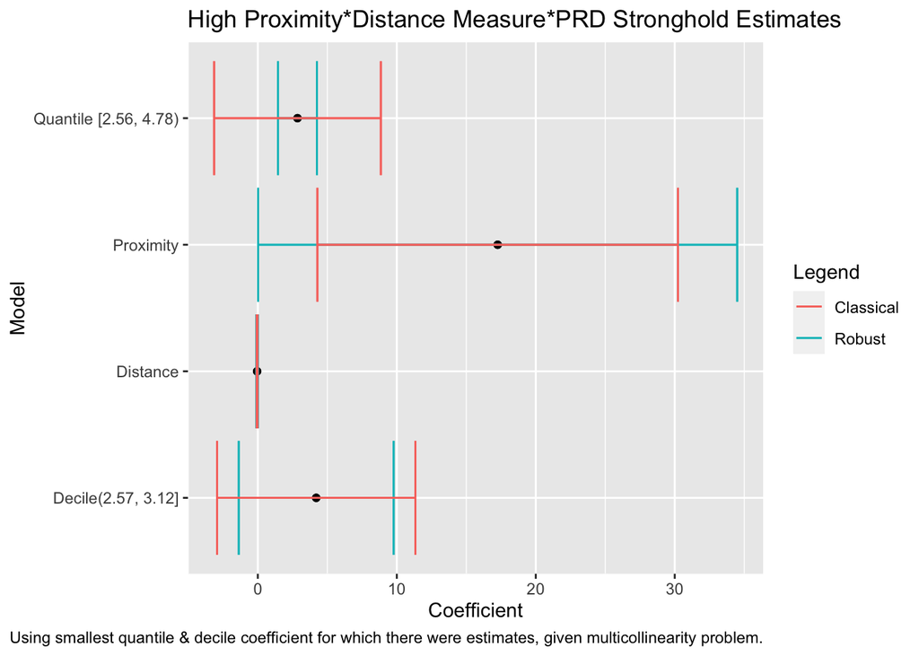

```r
df %>%
  ggplot(aes(x = coefficient, y = model)) +
  geom_point(aes(x = coefficient)) +
  geom_errorbarh(aes(xmin=lowerRSE,xmax=upperRSE, color = "red")) +
  geom_errorbarh(aes(xmin=lowerCSE,xmax=upperCSE, color = "blue")) +
  scale_color_discrete(name = "Legend", labels = c("Classical", "Robust")) +
 xlab("Coefficient") +
  ggtitle("High Proximity*Distance Measure*PRD Stronghold Estimates") +
  ylab("Model") +
  labs(caption = "Using smallest quantile & decile coefficient for which there were estimates, given multicollinearity problem.") -> se.plot

se.plot
```

```r
ggsave("se.plot.jpg", height = 5, width = 7)
```